# Estudios de Informática, Multimedia y Telecomunicaciones

#### 3.3.1.3 Comparativa de los tres algoritmos

El dataset ha demostrado ser un reto de clasificación en varios sentidos, primero por la aparición de una clase poco segregada que unifica a las otras dos, segundo por la variación en la desviación típica entre atributos y tercero por no disponer de demasiadas instancias. A pesar de eso, la comparativa entre algoritmos debería ser válida y deberíamos poder llegar a una conclusión sobre el uso de cada uno.

En cuanto a la calidad de los modelos, el uso de medoides no ha parecido subirla en los dos últimos algoritmos, aunque partiamos de una calidad bastante alta y dificilmente mejorable.

En cuanto al mapeo de los resultados, vamos a ver cómo ha variado el uso de cada algoritmo sobre los atributos que hemos considerado determinantes: Prolina y Flavanoides.

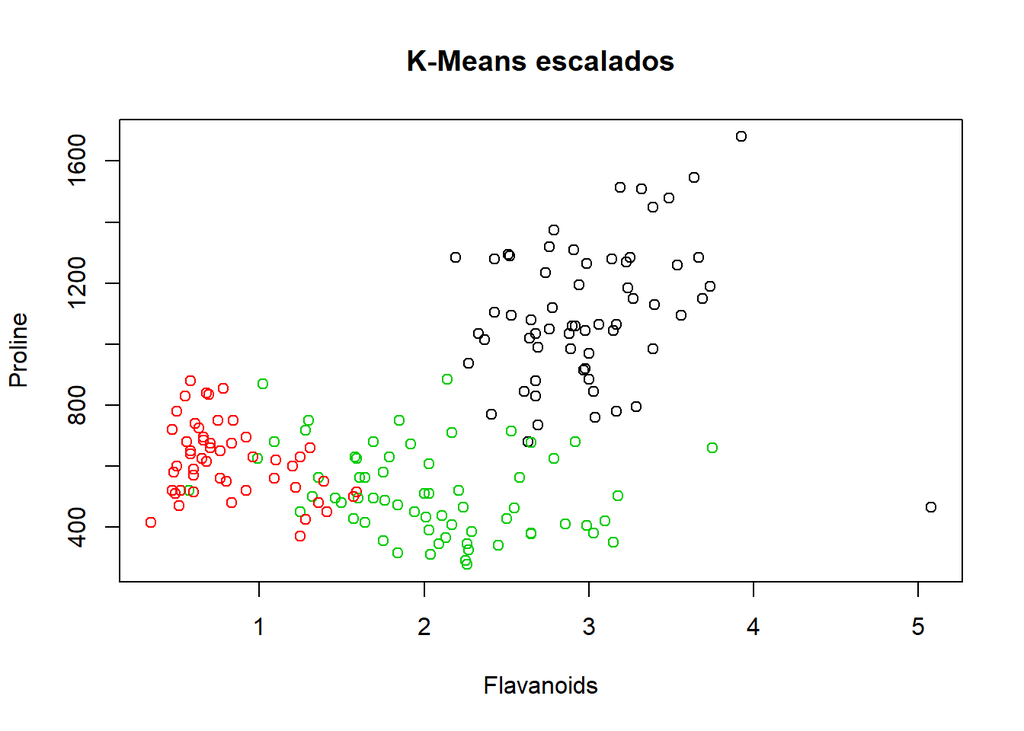

```r
plot(atributos[c(7,13)], col=vinos3.scaled$cluster, main = "K-Means escalados")
```

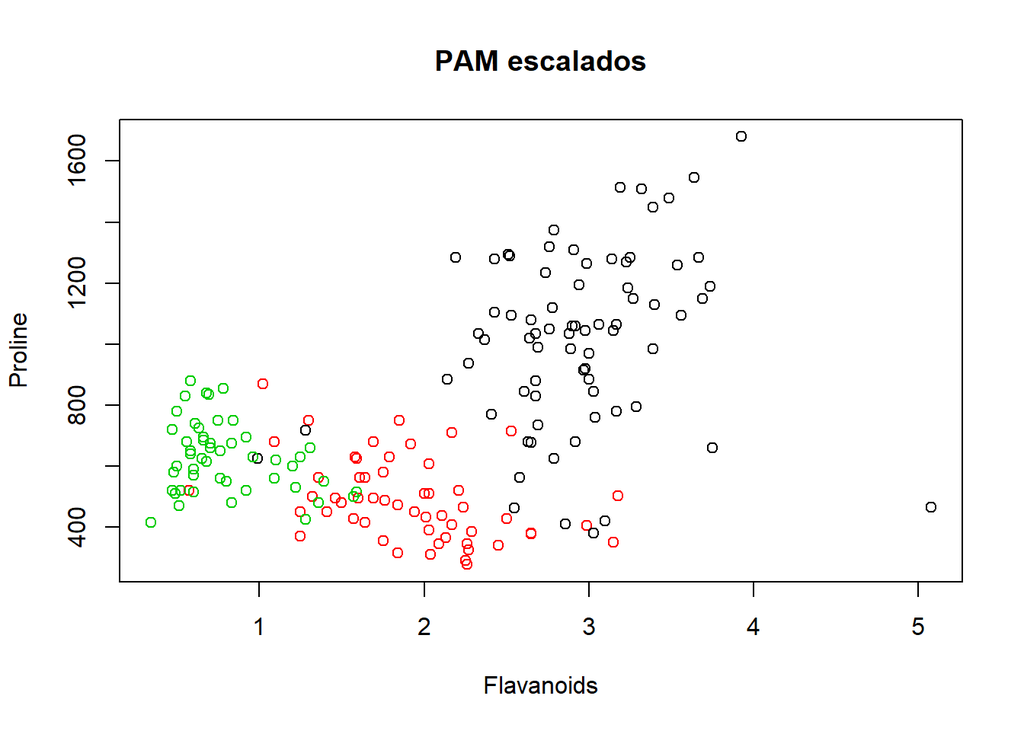

```r
plot(atributos[c(7,13)], col=atributos.pam.scaled$clustering, main = "PAM escalados")
```

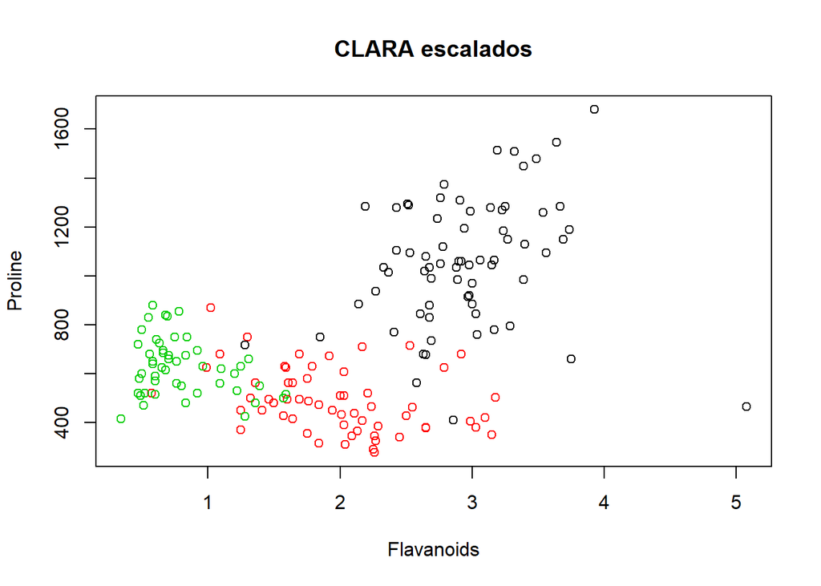

```r
plot(atributos[c(7,13)], col=atributos.clara.scaled$clustering, main = "CLARA escalados")
```

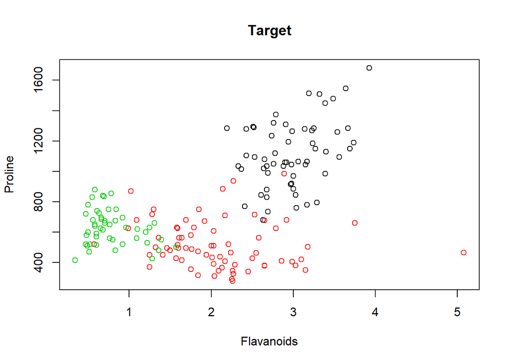

```r
plot(atributos[c(7,13)], col=datos[,1], main = "Target")
```

Las partes centradas de los grupos son bastante parecida para los tres, es en las periferias donde se encuentran las diferencias.

El mayor acierto de Kmeans ha sabido saber acertar con las periferias, identificando a uno de los puntos del grupo dos que se extendía hacia el valor cuatro de flavonoides, pero sobre todo distinguiendo entre las instancias del grupo 2 que se incluían en el 1.

Una vez hecho este análisis, no nos resulta extraño que el método Kmeans sea mucho más popular que los otros entre datasets pequeños/medios, mientras que CLARA parece una muy buena alternativa para datasets de gran tamaño.